# Implementing AdaBoost

When the trees in the forest are trees of depth 1 (also known as **decision stumps**) and we perform boosting instead of bagging, the resulting algorithm is called **AdaBoost**.

AdaBoost adjusts the dataset at each iteration by performing the following actions:

- Selecting a decision stump
- Increasing the weighting of cases that the decision stump labeled incorrectly while reducing the weighting of correctly labeled cases

This iterative weight adjustment causes each new classifier in the ensemble to prioritize training the incorrectly labeled cases. As a result, the model adjusts by targeting highly-weighted data points.

Eventually, the stumps are combined to form a final classifier.

# Implementing AdaBoost in OpenCV

```python
import cv2

img_bgr = cv2.imread('dani.jpg', cv2.IMREAD_COLOR)
img_gray = cv2.cvtColor(img_bgr, cv2.COLOR_BGR2GRAY)
```

```python
# load a pretrained Haar cascade
filename = 'data/haarcascade_frontalface_default.xml'
face_cascade = cv2.CascadeClassifier(filename)
```

```python
# detect faces, note that it only works on grayscale
faces = face_cascade.detectMultiScale(img_gray, 1.1,5)
```

```python
color = (255, 0, 0)
thickness = 2
for (x, y, w, h) in faces:
    cv2.rectangle(img_bgr, (x, y), (x + w, y + h),\
                 color, thickness)
```

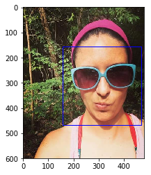

```python
# plot the image
import matplotlib.pyplot as plt
#%matplotlib inline
plt.imshow(cv2.cvtColor(img_bgr, cv2.COLOR_BGR2RGB))
plt.show()
```

# Implementing AdaBoost in scikit-learn

In scikit-learn, AdaBoost is just another ensemble estimator. We can create an ensemble from 100 decision stumps as follows

```python
from sklearn.ensemble import AdaBoostClassifier
ada = AdaBoostClassifier(n_estimators=100, random_state=456)
```

```python
# split the cancer dataset 75/25
from sklearn.datasets import load_breast_cancer
cancer = load_breast_cancer()
X = cancer.data
y = cancer.target
```

```python
from sklearn.model_selection import train_test_split
X_train, X_test, y_train, y_test = train_test_split(\
                                                   X,\
                                                    y,\
                                                    random_state=456)
```

```python
# fit and score
ada.fit(X_train, y_train)
ada.score(X_test, y_test)
#0.97
```

```
0.9790209790209791
```

We might want to compare this result to a random forest. However, to be fair, we should make the trees in the forest all decision stumps. Then we will know the difference between bagging and boosting:

```python
from sklearn.ensemble import RandomForestClassifier
forest = RandomForestClassifier(\
                              n_estimators = 100,\
                              max_depth = 1,\
                              random_state = 456)
forest.fit(X_train, y_train)
forest.score(X_test, y_test)
#0.93
```

```
0.9370629370629371
```

```python
# What happens if we let the trees be as deep as needed?
forest = RandomForestClassifier(\
                               n_estimators=100,\
                               random_state=456)
forest.fit(X_train, y_train)
forest.score(X_test, y_test)
#0.98
```

```
0.986013986013986
```

# References

(Beyeler, 2017) Michael Beyeler, ``*Machine Learning for OpenCV: Intelligent image processing with Python*'', 2017. [online](https://www.amazon.com/Machine-Learning-OpenCV-Intelligent-processing/dp/1783980281?SubscriptionId=AKIAIOBINVZYXZQZ2U3A&tag=chimbori05-20&linkCode=xm2&camp=2025&creative=165953&creativeASIN=1783980281)